# A stochastic meta-population model of LSDV epidemics

Thibaut Jombart

## Outline of the work

In this report, we use a stochastic, meta-population SEIRCDV model to simulate outbreaks of Lumpy skin disease virus. We contrast different response scenario:

1. **baseline**: no response
2. **cull_quarant_vacc scenario**: mass culling of infected farms, quarantine (local and ring), ring vaccination
3. **quarant_vacc**: quarantine (local and ring) and vaccination (local and ring)
4. **selcull_quarant_vacc**: selective culling (only individuals in $I$), quarantine (local and ring) and vaccination (local and ring)
5. **selcull_quarant_vacc_insect scenario**: all but mass culling (selective culling, vaccination, quarantine, insecticide)
6. **all**: all measures combined

## Simulation setup

### Required libraries

We load required libraries:

```r
library(tidyverse)
library(viridis)
```

```r
library(qs)
## qs 0.27.3. Announcement: https://github.com/qsbase/qs/issues/103
library(here)
## here() starts at C:/dev/lsdsim
library(digest)
library(compiler)
library(rio)
library(cowplot)
devtools::load_all()
## ℹ Loading lsdsim
```

## Population setting

```r
n_rep <- params$n_rep
duration <- 365
grid_size <- 40
n_pop <- grid_size^2
xy <- make_grid(grid_size)
```

The size of the farms, in number of herds, is drawn using an average herd size of 50, exponentially distributed with a minimum at 20 individuals:

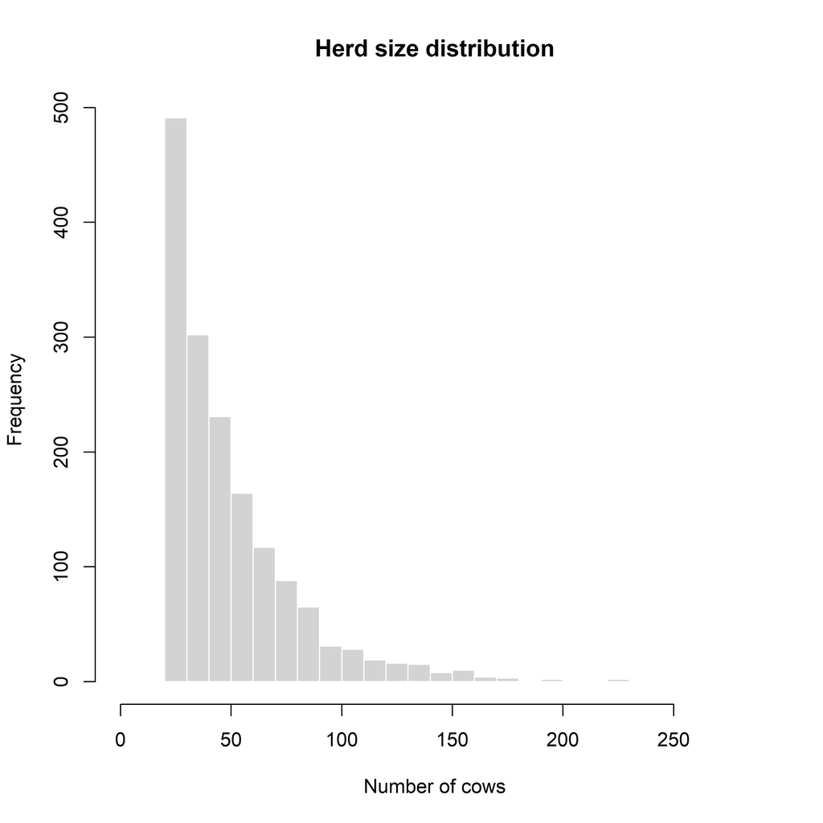

```r
r_herd_size <- function(n) {
  20 + round(rexp(nrow(xy), 1/30))
}

herd_size <- r_herd_size(1e4)
hist(herd_size, border = "white",
     main = "Herd size distribution",
     xlab = "Number of cows",
     nclass = 30,
     xlim = c(0, max(herd_size)))
```

```r
summary(herd_size)
```

[output not shown]

```r
herds <- cbind.data.frame(xy, size = r_herd_size(n_pop))
```

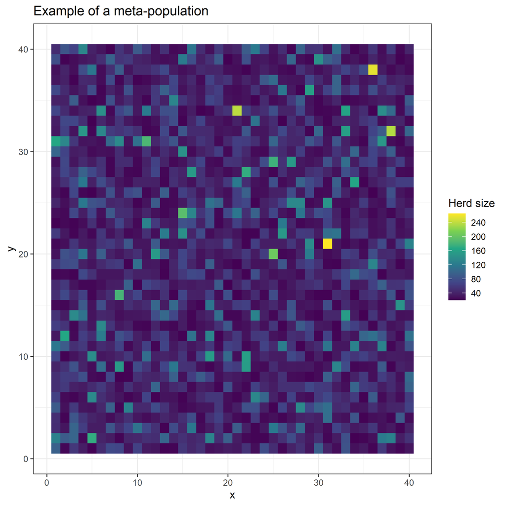

```r
ggplot(herds, aes(x = x, y = y)) +
  geom_tile(aes(fill = size)) +
  theme_bw() +
  scale_fill_viridis_c("Herd size", n.breaks = 8) +
  labs(title = "Example of a meta-population")
```

In practice, every simulation will use a different population setting (randomly drawn herd sizes).

## Seasonality

Seasonality is likely to affect transmissibility via changes in vector populations (‘beta’ term in the model). We build a simple function that will create *R* values seasonal fluctuations using a cosine:

```r
#' param t: a vector of integers representing days
R_season <- function(start = 1, duration = 365, min_R = 2, max_R = 20) {
  t <- seq(start, by = 1, length.out = duration)
  out <- cos(2 * pi * (t)/ 365)
  # rescale to [0 ; 1]
  out <- out - min(out)
  out <- out / max(out)

  ## scale to [min_R ; max_R]
  out <- out * (max_R - min_R)
  out <- out + min_R
  out
}
```

A random starting point will enable simulating seasonality with an outbreak seeded at any point in the year. We illustrate 10 trajectories with a random start:

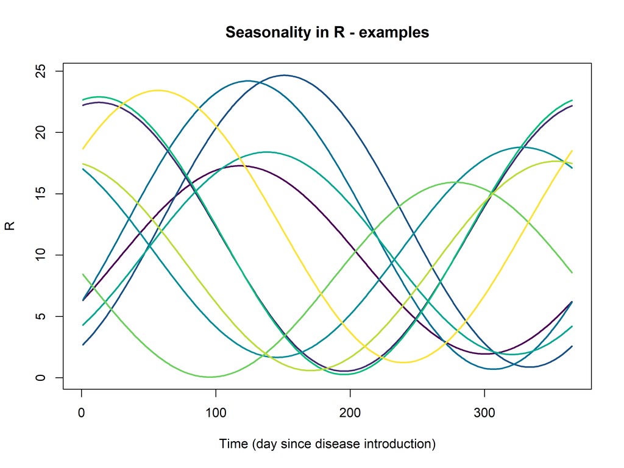

```r
R_demo <- lapply(1:10, function(i) R_season(
  start = sample(1:365, 1),
  min_R = runif(1, 0, 2),
  max_R = runif(1, 15, 25))) %>%
  data.frame()
matplot(R_demo,
        x = 1:365,
        xlab = "Time (day since disease introduction)",
        ylab = "R", type = "l", col = hcl.colors(10), lty = 1, lwd = 2,
        main = "Seasonality in R - examples")
```

## Simulations

### General settings

We set the number of replicates, which will apply to each simulation scenario. We also make a compiled version of `lsdsim` and set up initial conditions.

```r
fast_lsdsim <- compiler::cmpfun(lsdsim)
```

This function is used to generate one new case in a randomly chosen population, to seed outbreaks:

```r
r_ini_case <- function(n_pop) {
  out <- rep(0, n_pop)
  out[sample.int(n_pop, 1)] <- 1
  out
}
```

Input parameters will be the same for different interventions. We need to uses the values of *R* drawn from the literature generated by `rlsd_param` with values fluctuating over time (seasonality), both for symptomatic and asymptomatic cases.

```r
lsd_params <- rlsd_param(n_rep)
head(lsd_params)
```

```
##       R0_I     R0_A   latent infec_period        cfr    pasymp   beta_I
## 1 20.16764 1.740942 7.366904     8.761859 0.03041798 0.5077491 2.301753
## 2 19.79453 1.852755 8.360274     8.748649 0.02465021 0.5408347 2.262581
## 3 20.54244 2.195071 8.210977     9.079335 0.01969693 0.4882512 2.262549
## 4 20.39844 1.841726 8.325875     9.452608 0.02709598 0.5223774 2.157969
## 5 20.25808 1.888889 8.715768     8.768966 0.03371457 0.5342960 2.310202
## 6 19.55189 2.001035 7.697993     8.414090 0.02043976 0.4738647 2.323709
##      beta_A     sigma     gamma
## 1 0.1986955 0.1357422 0.1141310
## 2 0.2117761 0.1196133 0.1143034
## 3 0.2417656 0.1217882 0.1101402
## 4 0.1948379 0.1201075 0.1057909
## 5 0.2154061 0.1147346 0.1140385
## 6 0.2378195 0.1299040 0.1188483
```

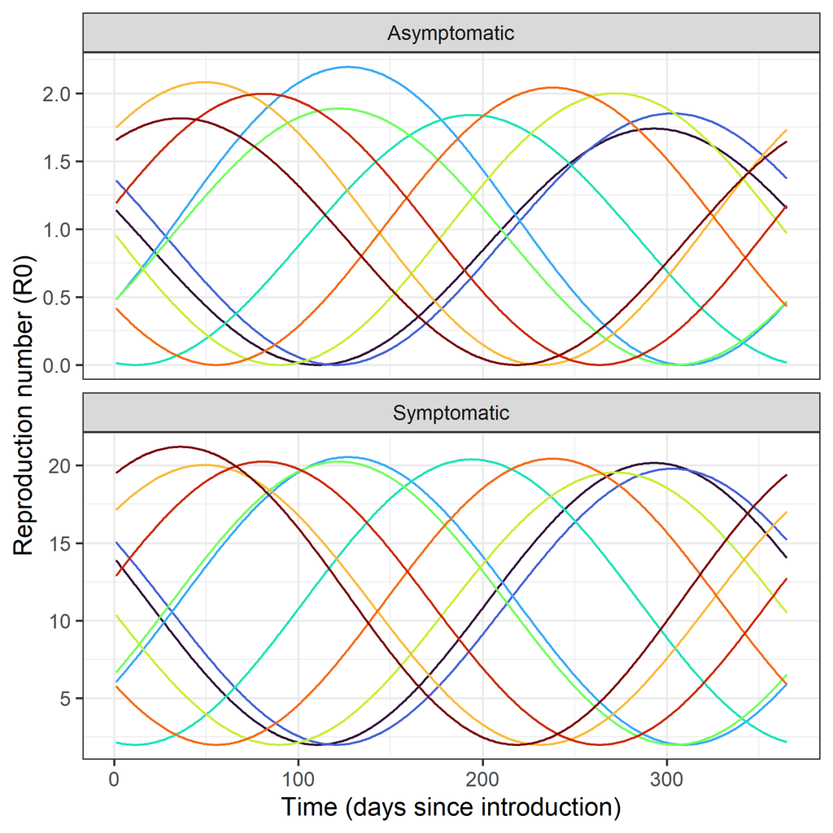

```r
start_dates <- sample.int(365, n_rep, replace = TRUE)
R0_I_season <- lapply(
  seq_len(n_rep),
  function(i) R_season(start = start_dates[i],
                       max_R = lsd_params$R0_I[i],
                       min_R = 2)
  )
R0_A_season <- lapply(
  seq_len(n_rep),
  function(i) R_season(start = start_dates[i],
                       max_R = lsd_params$R0_A[i],
                       min_R = 0)
  )

## We make a figure keep at most the first 10 simulated time series:
R_over_time <- data.frame(
  Symptomatic = unlist(head(R0_I_season, 10)),
  Asymptomatic = unlist(head(R0_A_season, 10)),
  time = 1:365
)
n_sim_kept <- min(10, n_rep)
R_over_time$sim = rep(1:n_sim_kept, each = 365)

R_over_time %>%
  pivot_longer(1:2, values_to = "R", names_to = "Source") %>%
  ggplot(aes(x = time, y = R)) +
  geom_line(aes(group = sim, color = factor(sim))) +
  guides(color = "none") +
  scale_color_viridis_d(option = "turbo") +
  facet_wrap(~Source, nrow = 2, scales = "free_y") +
  theme_bw() +
  labs(x = "Time (days since introduction)", y = "Reproduction number (R0)")
```

R0 are translated into betas and the rest of the inputs are generated:

```r
beta_I_season <- lapply(
  seq_along(R0_I_season),
  function(i) R0_I_season[[i]] * lsd_params$gamma[i]
)
beta_A_season <- lapply(
  seq_along(R0_A_season),
  function(i) R0_A_season[[i]] * lsd_params$gamma[i]
)


list_herd_size <- lapply(1:n_rep, function(i) r_herd_size(n_pop))
list_ini_cases <- lapply(1:n_rep, function(i) r_ini_case(n_pop))

## variability in interventions:
##
## - response time 2-14 days
## - quarantine efficacy within: 0-20%
## - quarantine efficacy outwards: 80-100%
## - insecticide efficacy: 50-95%

inputs <- tibble(
  lsd_params %>% select(-c(beta_I, beta_A)),
  ini_S = list_herd_size,
  ini_I = list_ini_cases,
  beta_I = beta_I_season,
  beta_A = beta_A_season,
  interv_delay = sample(2:14, replace = TRUE, size = n_rep),
  quarant_eff_in = runif(n_rep, min = 0, max = 0.2),
  quarant_eff_out = runif(n_rep, min = 0.8, max = 1),
  insect_eff = runif(n_rep, min = 0.5, max = 0.95)
)

inputs$label <- apply(inputs, 1, function(e) substr(digest(e), 1, 8))
```

We also need to pre-generate delta matrices for each simulation. As they are large, we need to store them as separate files as they would otherwise clog the RAM:

```r
delta_dir <- here::here("outputs", "delta")
dir.create(delta_dir)

for (i in seq_len(n_rep)) {
  ## the  delta is generated on the fly to avoid tremendous RAM requirements; we
  ## proceed as follows:
  ##
  ## generate the delta matrix from the rook connectivity with diffusion ranging
  ## 1-10% from one location to another; there are 1-5% of cliques, which are
  ## connected to 1-3% of all other populations)
  delta <- make_delta(xy,
                      diffusion = runif(nrow(xy), min = 0.01, max = 0.1),
                      p_clique = runif(1, min = 0.01, max = 0.05),
                      clique_connect = sample(5:30, 1)
  )
  file_name <- paste0("delta_", i, ".qs")
  qsave(delta, file.path(delta_dir, file_name))

}

delta_files <- list.files(delta_dir, full.names = TRUE)
```

### *baseline* scenario: no response

In these simulations, we use no response.

```r
output_dir <- here::here("outputs", "simulations", "baseline", Sys.Date())
if (!dir.exists(output_dir)) {
  dir.create(output_dir, recursive = TRUE)
}

res_baseline <- vector(mode = "list", length = n_rep)
for (i in seq_len(n_rep)) {

  ## read a delta file for this simulation
  delta <- qread(delta_files[i])

  ## run simulation
  current_sim <- fast_lsdsim(
    grid_size = grid_size,
    time = duration,
    ini_S = unlist(inputs$ini_S[[i]]),
    ini_I = unlist(inputs$ini_I[[i]]),
    delta = delta,
    beta_A = inputs$beta_A[[i]],
    beta_I = inputs$beta_I[[i]],
    sigma = inputs$sigma[i],
    gamma = inputs$gamma[i],
    pasymp = inputs$pasymp[i],
    cfr = inputs$cfr[i],
    quarantine = FALSE,
    vaccination = FALSE,
    mass_culling = FALSE,
    select_culling = FALSE,
    insecticide = FALSE
  )

  ## save full simulation to file
  out_file <- file.path(
    output_dir,
    paste0(inputs$label[i], "_baseline", ".qs")
  )
  qsave(current_sim, out_file)

  ## store summary
  res_baseline[[i]] <- summary(current_sim)[duration, ]
}

res_baseline <- cbind(label = inputs$label, bind_rows(res_baseline))
head(res_baseline)
summary(res_baseline)

qsave(res_baseline, file.path(output_dir, "summary.qs"))
rio::export(res_baseline, file.path(output_dir, "summary.xlsx"))
```

### *cull_quarant_vacc* scenario: mass culling and ring vaccination

In these simulations, we use:

- mass culling of the affected herds
- ring vaccination (i.e. vaccination of neighbours)

```r
output_dir <- here::here("outputs", "simulations", "cull_quarant_vacc", Sys.Date())
if (!dir.exists(output_dir)) {
  dir.create(output_dir, recursive = TRUE)
}

res_cull_quarant_vacc <- vector(mode = "list", length = n_rep)
for (i in seq_len(n_rep)) {

  ## read a delta file for this simulation
  delta <- qread(delta_files[i])

  ## run simulation
  current_sim <- fast_lsdsim(
    grid_size = grid_size,
    time = duration,
    ini_S = unlist(inputs$ini_S[[i]]),
    ini_I = unlist(inputs$ini_I[[i]]),
    delta = delta,
    beta_A = inputs$beta_A[[i]],
    beta_I = inputs$beta_I[[i]],
    sigma = inputs$sigma[i],
    gamma = inputs$gamma[i],
    pasymp = inputs$pasymp[i],
    cfr = inputs$cfr[i],
    quarantine = TRUE,
    vaccination = TRUE,
    mass_culling = TRUE,
    select_culling = FALSE,
    insecticide = FALSE,
    interv_delay = inputs$interv_delay[i],
    quarant_efficacy_in = inputs$quarant_eff_in[i],
    quarant_efficacy_out = inputs$quarant_eff_out[i],
    interv_release = 28,
    vacc_coverage = 1,
    vacc_efficacy = 0.65/21,
    rate_cull = 1e30
  )

  ## save full simulation to file
  out_file <- file.path(
    output_dir,
    paste0(inputs$label[i], "_cull_quarant_vacc", ".qs")
  )
  qsave(current_sim, out_file)

  ## store summary
  res_cull_quarant_vacc[[i]] <- summary(current_sim)[duration, ]
}

res_cull_quarant_vacc <- cbind(label = inputs$label, bind_rows(res_cull_quarant_vacc))
head(res_cull_quarant_vacc)
summary(res_cull_quarant_vacc)

qsave(res_cull_quarant_vacc, file.path(output_dir, "summary.qs"))
rio::export(res_cull_quarant_vacc, file.path(output_dir, "summary.xlsx"))
```

### *quarant_vacc* scenario: quarantine and ring vaccination

In these simulations, we use:

- quarantine of infected herds and neighbours
- vaccination of infected herds and neighbours

```r
output_dir <- here::here("outputs", "simulations", "quarant_vacc", Sys.Date())
if (!dir.exists(output_dir)) {
  dir.create(output_dir, recursive = TRUE)
}

res_quarant_vacc <- vector(mode = "list", length = n_rep)
for (i in seq_len(n_rep)) {

  ## read a delta file for this simulation
  delta <- qread(delta_files[i])

  ## run simulation
  current_sim <- fast_lsdsim(
    grid_size = grid_size,
    time = duration,
    ini_S = unlist(inputs$ini_S[[i]]),
    ini_I = unlist(inputs$ini_I[[i]]),
    delta = delta,
    beta_A = inputs$beta_A[[i]],
    beta_I = inputs$beta_I[[i]],
    sigma = inputs$sigma[i],
    gamma = inputs$gamma[i],
    pasymp = inputs$pasymp[i],
    cfr = inputs$cfr[i],
    quarantine = TRUE,
    vaccination = TRUE,
    mass_culling = FALSE,
    select_culling = FALSE,
    insecticide = FALSE,
    interv_delay = inputs$interv_delay[i],
    quarant_efficacy_in = inputs$quarant_eff_in[i],
    quarant_efficacy_out = inputs$quarant_eff_out[i],
    interv_release = 28,
    vacc_coverage = 1,
    vacc_efficacy = 0.65/21
  )

  ## save full simulation to file
  out_file <- file.path(
    output_dir,
    paste0(inputs$label[i], "_quarant_vacc", ".qs")
  )
  qsave(current_sim, out_file)

  ## store summary
  res_quarant_vacc[[i]] <- summary(current_sim)[duration, ]
}

res_quarant_vacc <- cbind(label = inputs$label, bind_rows(res_quarant_vacc))
head(res_quarant_vacc)
summary(res_quarant_vacc)

qsave(res_quarant_vacc, file.path(output_dir, "summary.qs"))
rio::export(res_quarant_vacc, file.path(output_dir, "summary.xlsx"))
```

### *selcull_quarant_vacc* scenario: selective culling, quarantine and ring vaccination

In these simulations, we use:

- selective culling of infected individuals
- quarantine of infected herds and neighbours
- vaccination of infected herds and neighbours

```r
output_dir <- here::here("outputs", "simulations", "selcull_quarant_vacc", Sys.Date())
if (!dir.exists(output_dir)) {
  dir.create(output_dir, recursive = TRUE)
}

res_selcull_quarant_vacc <- vector(mode = "list", length = n_rep)
for (i in seq_len(n_rep)) {

  ## read a delta file for this simulation
  delta <- qread(delta_files[i])

  ## run simulation
  current_sim <- fast_lsdsim(
    grid_size = grid_size,
    time = duration,
    ini_S = unlist(inputs$ini_S[[i]]),
    ini_I = unlist(inputs$ini_I[[i]]),
    delta = delta,
    beta_A = inputs$beta_A[[i]],
    beta_I = inputs$beta_I[[i]],
    sigma = inputs$sigma[i],
    gamma = inputs$gamma[i],
    pasymp = inputs$pasymp[i],
    cfr = inputs$cfr[i],
    quarantine = TRUE,
    vaccination = TRUE,
    mass_culling = FALSE,
    select_culling = TRUE,
    insecticide = FALSE,
    interv_delay = inputs$interv_delay[i],
    quarant_efficacy_in = inputs$quarant_eff_in[i],
    quarant_efficacy_out = inputs$quarant_eff_out[i],
    interv_release = 28,
    vacc_efficacy = 0.65/21,
    rate_cull = 1e30 # immediate culling
  )

  ## save full simulation to file
  out_file <- file.path(
    output_dir,
    paste0(inputs$label[i], "_selcull_quarant_vacc", ".qs")
  )
  qsave(current_sim, out_file)

  ## store summary
  res_selcull_quarant_vacc [[i]] <- summary(current_sim)[duration, ]
}

res_selcull_quarant_vacc  <- cbind(
  label = inputs$label,
  bind_rows(res_selcull_quarant_vacc )
)

head(res_selcull_quarant_vacc )
summary(res_selcull_quarant_vacc)

qsave(res_selcull_quarant_vacc, file.path(output_dir, "summary.qs"))
rio::export(res_selcull_quarant_vacc, file.path(output_dir, "summary.xlsx"))
```

### *selcull_quarant_vacc_insect* scenario: selective culling, quarantine, ring vaccination, insecticide (all but mass culling)

In these simulations, we use:

- selective culling of infected individuals
- quarantine of infected herds and neighbours
- vaccination of infected herds and neighbours
- insecticide spray of infected herds and neighbours

```r
output_dir <- here::here("outputs", "simulations", "selcull_quarant_vacc_insect", Sys.Date())
if (!dir.exists(output_dir)) {
  dir.create(output_dir, recursive = TRUE)
}

res_selcull_quarant_vacc_insect <- vector(mode = "list", length = n_rep)
for (i in seq_len(n_rep)) {

  ## read a delta file for this simulation
  delta <- qread(delta_files[i])

  ## run simulation
  current_sim <- fast_lsdsim(
    grid_size = grid_size,
    time = duration,
    ini_S = unlist(inputs$ini_S[[i]]),
    ini_I = unlist(inputs$ini_I[[i]]),
    delta = delta,
    beta_A = inputs$beta_A[[i]],
    beta_I = inputs$beta_I[[i]],
    sigma = inputs$sigma[i],
    gamma = inputs$gamma[i],
    pasymp = inputs$pasymp[i],
    cfr = inputs$cfr[i],
    quarantine = TRUE,
    vaccination = TRUE,
    mass_culling = FALSE,
    select_culling = TRUE,
    insecticide = TRUE,
    interv_delay = inputs$interv_delay[i],
    quarant_efficacy_in = inputs$quarant_eff_in[i],
    quarant_efficacy_out = inputs$quarant_eff_out[i],
    insect_efficacy = inputs$insect_eff[i],
    interv_release = 28,
    vacc_coverage = 1,
    vacc_efficacy = 0.65/21,
    rate_cull = 1e30
  )

  ## save full simulation to file
  out_file <- file.path(
    output_dir,
    paste0(inputs$label[i], "_selcull_quarant_vacc_insect", ".qs")
  )
  qsave(current_sim, out_file)

  ## store summary
  res_selcull_quarant_vacc_insect[[i]] <- summary(current_sim)[duration, ]
}

res_selcull_quarant_vacc_insect <- cbind(label = inputs$label, bind_rows(res_selcull_quarant_vacc_insect))
head(res_selcull_quarant_vacc_insect)
summary(res_selcull_quarant_vacc_insect)

qsave(res_selcull_quarant_vacc_insect, file.path(output_dir, "summary.qs"))
rio::export(res_selcull_quarant_vacc_insect, file.path(output_dir, "summary.xlsx"))
```

### all scenario: mass culling, quarantine, ring vaccination, insecticide

In these simulations, we use mass culling, ring quarantine and vaccination, and insecticide spray.

```r
output_dir <- here::here("outputs", "simulations", "all", Sys.Date())
if (!dir.exists(output_dir)) {
  dir.create(output_dir, recursive = TRUE)
}

res_all <- vector(mode = "list", length = n_rep)
for (i in seq_len(n_rep)) {

  ## read a delta file for this simulation
  delta <- qread(delta_files[i])

  ## run simulation
  current_sim <- fast_lsdsim(
    grid_size = grid_size,
    time = duration,
    ini_S = unlist(inputs$ini_S[[i]]),
    ini_I = unlist(inputs$ini_I[[i]]),
    delta = delta,
    beta_A = inputs$beta_A[[i]],
    beta_I = inputs$beta_I[[i]],
    sigma = inputs$sigma[i],
    gamma = inputs$gamma[i],
    pasymp = inputs$pasymp[i],
    cfr = inputs$cfr[i],
    interv_delay = inputs$interv_delay[i],
    quarant_efficacy_in = inputs$quarant_eff_in[i],
    quarant_efficacy_out = inputs$quarant_eff_out[i],
    insect_efficacy = inputs$insect_eff[i],
    quarantine = TRUE,
    vaccination = TRUE,
    mass_culling = TRUE,
    select_culling = TRUE, # redundant with mass culling but for consistency
    insecticide = TRUE,
    interv_release = 28,
    vacc_coverage = 1,
    vacc_efficacy = 0.65/21,
    rate_cull = 1e30
  )

  ## save full simulation to file
  out_file <- file.path(
    output_dir,
    paste0(inputs$label[i], "_all", ".qs")
  )
  qsave(current_sim, out_file)

  ## store summary
  res_all[[i]] <- summary(current_sim)[duration, ]
}

res_all <- cbind(label = inputs$label, bind_rows(res_all))
head(res_all)
summary(res_all)

qsave(res_all, file.path(output_dir, "summary.qs"))
rio::export(res_all, file.path(output_dir, "summary.xlsx"))
```

## Analyses

```r
res_baseline$scenario <- "baseline"
res_cull_quarant_vacc$scenario <- "cull_quarant_vacc"
res_quarant_vacc$scenario <- "quarant_vacc"
res_selcull_quarant_vacc$scenario <- "selcull_quarant_vacc"
res_selcull_quarant_vacc_insect$scenario <- "selcull_quarant_vacc_insect"
res_all$scenario <- "all"

res <- bind_rows(
  res_baseline,
  res_cull_quarant_vacc,
  res_quarant_vacc,
  res_selcull_quarant_vacc,
  res_selcull_quarant_vacc_insect,
  res_all
  ) %>%
  select(scenario, everything()) %>%
  mutate(
    p_immun = (R + V) / N,
    p_dead = (D + C) / (N + D + C),
    scenario = factor(
      scenario, levels = c(
        "baseline",
        "cull_quarant_vacc",
        "quarant_vacc",
        "selcull_quarant_vacc",
        "selcull_quarant_vacc_insect",
        "all")
      )
  )

file_name <- paste0("res_", Sys.Date(), ".qs")
qsave(res, here::here("outputs", file_name))
```

This is evaluated only if new results have not been obtained, fetching the latest version of the results:

```r
all_files <- list.files(here::here("outputs"), pattern = "^res")
extract_date <- function(x) {
  out <- gsub("[^[:digit:]-]", "", x)
  as.Date(out)
}
dates <- sapply(all_files, extract_date)
to_keep <- which.max(dates)
file_to_keep <- all_files[to_keep]
file_to_keep
```

```
## [1] "res_2026-05-09.qs"
```

```r
message("reading results from file:", file_to_keep)
## reading results from file:res_2026-05-09.qs
res <- qread(here::here("outputs", file_to_keep))
```

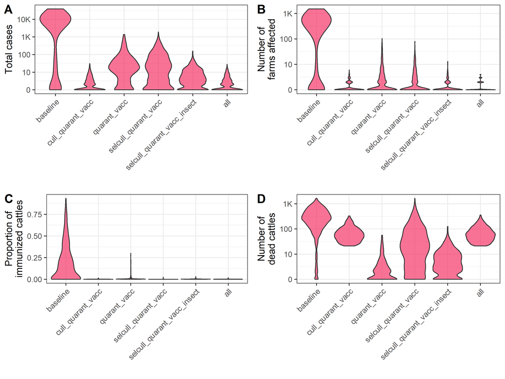

```r
label_numbers <- function(x, show_1_as_0 = FALSE) {
  out <- scales::label_number(scale_cut = scales::cut_long_scale())(x)
  if (show_1_as_0) {
    out[out=="1"] <- "0"
  }
  out
}

p_cases <- ggplot(res, aes(x = scenario, y = total_cases)) +
  geom_violin(scale = "width", fill = "#F5275E", alpha = 0.65) +
  scale_y_continuous(
    transform = "log10",
    labels = function(e) label_numbers(e, show_1_as_0 = TRUE)
  ) +
  theme_bw() +
  labs(
    x = "",
    y = "Total cases"
  )

p_n_pop <- ggplot(res, aes(x = scenario, y = n_pop_ever_infec)) +
  geom_violin(scale = "width", fill = "#F5275E", alpha = 0.65) +
  scale_y_continuous(
    transform = "log10",
    labels = function(e) label_numbers(e, show_1_as_0 = TRUE)
  ) +
  theme_bw() +
  labs(
    x = "",
    y = "Number of\nfarms affected"
    )


p_immun <- ggplot(res, aes(x = scenario, y = p_immun)) +
  geom_violin(scale = "width", fill = "#F5275E", alpha = 0.65) +
  theme_bw() +
  labs(
    x = "",
    y = "Proportion of\nimmunized cattles"
    )

p_dead <- ggplot(res, aes(x = scenario, y = (D+C))) +
  geom_violin(scale = "width", fill = "#F5275E", alpha = 0.65) +
  scale_y_continuous(
    transform = "log10",
    labels = function(e) label_numbers(e, show_1_as_0 = TRUE)
  ) +
  theme_bw() +
  labs(
    x = "",
    y = "Number of\ndead cattles"
  )

rotated_x <- theme(
  axis.text.x = element_text(angle = 45, vjust = 1, hjust=1)
  )

plot_grid(
  p_cases + rotated_x,
  p_n_pop + rotated_x,
  p_immun + rotated_x,
  p_dead + rotated_x,
  labels = LETTERS[1:4]
)
```

Some summary statistics:

```r
# f_smry <- function(x) {
#   out <- c(
#     mean = mean(x),
#     median = median(x),
#     CI_95 = sprintf("[%f;%f]",
#                     quantile(x, 0.025),
#                     quantile(x, 0.975)
#                     )
#   )
# }

# total cases
res %>%
  group_by(scenario) %>%
  summarise(
    mean_cases = mean(total_cases) %>% label_numbers(),
    median_cases = median(total_cases) %>% label_numbers(),
    cases_0.025 = quantile(total_cases, 0.025) %>% label_numbers(),
    cases_0.975 = quantile(total_cases, 0.975) %>% label_numbers(),
    p_greater_100_cases = mean(total_cases >= 100)
  ) %>%
  knitr::kable(digits = 4)
```

| scenario | mean_cases | median_cases | cases_0.025 | cases_0.975 | p_greater_100_cases |
| --- | --- | --- | --- | --- | --- |
| baseline | 9K | 6K | 1 | 31K | 0.705 |
| cull_quarant_vacc | 3 | 2 | 1 | 13 | 0.000 |
| quarant_vacc | 56 | 17 | 1 | 452 | 0.113 |
| selcull_quarant_vacc | 52 | 12 | 1 | 350 | 0.147 |
| selcull_quarant_vacc_insect | 8 | 4 | 1 | 38 | 0.004 |
| all | 3 | 2 | 1 | 13 | 0.000 |

```r
# attack rates
res %>%
  group_by(scenario) %>%
  summarise(
    mean_ar = mean(ar),
    median_ar = median(ar),
    ar_0.025 = quantile(ar, 0.025),
    ar_0.975 = quantile(ar, 0.975)
  ) %>%
  knitr::kable(digits = 4)
```

| scenario | mean_ar | median_ar | ar_0.025 | ar_0.975 |
| --- | --- | --- | --- | --- |
| baseline | 0.1070 | 0.0781 | 0 | 0.3891 |
| cull_quarant_vacc | 0.0000 | 0.0000 | 0 | 0.0002 |
| quarant_vacc | 0.0007 | 0.0002 | 0 | 0.0056 |
| selcull_quarant_vacc | 0.0007 | 0.0002 | 0 | 0.0044 |
| selcull_quarant_vacc_insect | 0.0001 | 0.0000 | 0 | 0.0005 |
| all | 0.0000 | 0.0000 | 0 | 0.0002 |

```r
# deaths
res %>%
  group_by(scenario) %>%
  summarise(
    mean_deaths = mean(C+D) %>% label_numbers(),
    median_deaths = median(C+D) %>% label_numbers(),
    deaths_0.025 = quantile(C+D, 0.025) %>% label_numbers(),
    deaths_0.975 = quantile(C+D, 0.975) %>% label_numbers()
  ) %>%
  knitr::kable()
```

| scenario | mean_deaths | median_deaths | deaths_0.025 | deaths_0.975 |
| --- | --- | --- | --- | --- |
| baseline | 236 | 154 | 0 | 938 |
| cull_quarant_vacc | 73 | 58 | 23 | 222 |
| quarant_vacc | 2 | 0 | 0 | 14 |
| selcull_quarant_vacc | 48 | 11 | 0 | 320 |
| selcull_quarant_vacc_insect | 7 | 3 | 0 | 31 |
| all | 74 | 58 | 23 | 218 |

```r
# farms affected
res %>%
  group_by(scenario) %>%
  summarise(
    mean_farms = mean(n_pop_ever_infec),
    median_farms = median(n_pop_ever_infec),
    farms_0.025 = quantile(n_pop_ever_infec, 0.025),
    farms_0.975 = quantile(n_pop_ever_infec, 0.975)
    ) %>%
  knitr::kable(digits = 2)
```

| scenario | mean_farms | median_farms | farms_0.025 | farms_0.975 |
| --- | --- | --- | --- | --- |
| baseline | 406.88 | 328.5 | 1 | 1312.03 |
| cull_quarant_vacc | 1.35 | 1.0 | 1 | 3.00 |
| quarant_vacc | 4.06 | 1.0 | 1 | 29.02 |
| selcull_quarant_vacc | 3.07 | 1.0 | 1 | 18.00 |
| selcull_quarant_vacc_insect | 1.45 | 1.0 | 1 | 4.02 |
| all | 1.36 | 1.0 | 1 | 3.00 |